# Отчёт по лабораторной работе №14

Настройка файловых служб Samba

Бызова Мария Олеговна

2025-12-05

# Цель работы

## Цель работы

Целью данной лабораторной работы является приобретение навыков настройки доступа групп пользователей к общим ресурсам по протоколу SMB.

# Задание

## Задание

1. Установить и настроить сервер Samba.
2. Настроить на клиенте доступ к разделяемым ресурсам.
3. Написать скрипты для Vagrant, фиксирующие действия по установке и настройке сервера Samba для доступа к разделяемым ресурсам во внутреннем окружении виртуальных машин server и client. Внести соответствующие изменения в Vagrantfile.

# Выполнение лабораторной работы

## Настройка сервера Samba

На сервере установлены необходимые пакеты для работы Samba (рис. 1).

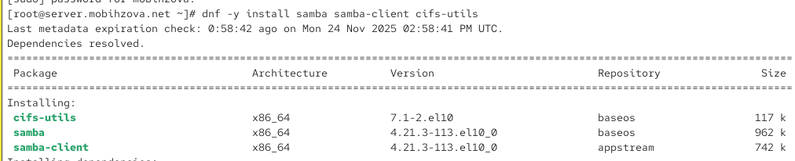

Рисунок 1: Установка пакетов samba, samba-client и cifs-utils на сервере

## Настройка сервера Samba

Создана группа `sambagroup` и добавлен пользователь `mobihzova` в эту группу (рис. 2).

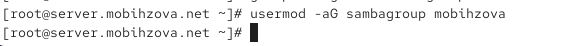

Рисунок 2: Добавление пользователя mobihzova в группу sambagroup

## Настройка сервера Samba

Создан общий каталог `/srv/sambashare` для хранения разделяемых ресурсов (рис. 3).

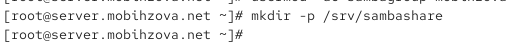

Рисунок 3: Создание каталога /srv/sambashare

## Настройка сервера Samba

Настроен основной файл конфигурации Samba `/etc/samba/smb.conf` с указанием рабочей группы `mobihzova-NET` (рис. 4).

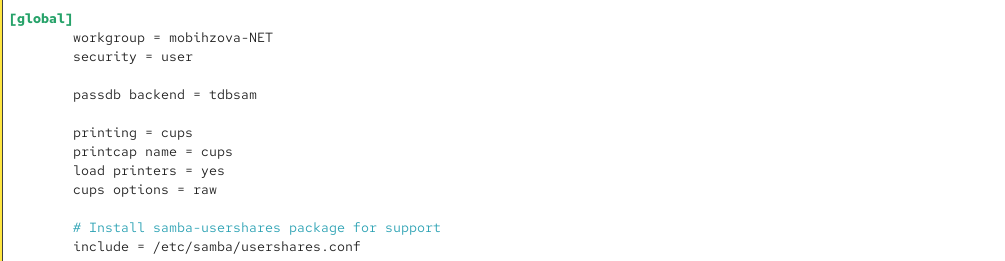

Рисунок 4: Основные настройки глобальной секции в smb.conf

## Настройка сервера Samba

Добавлена секция `[sambashare]` для общего ресурса (рис. 5).

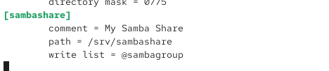

Рисунок 5: Конфигурация общего ресурса sambashare

## Настройка сервера Samba

Проверена корректность конфигурации с помощью команды `testparm` (рис. 6).

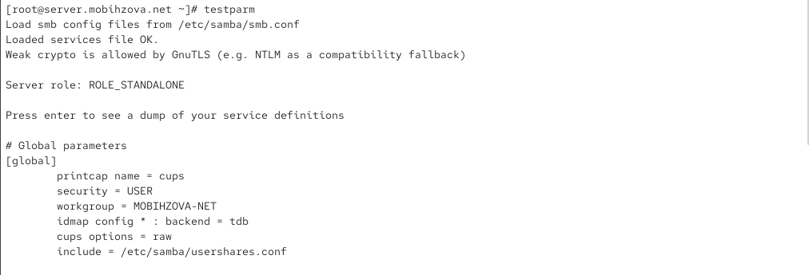

Рисунок 6: Проверка конфигурации Samba командой testparm

## Настройка сервера Samba

Запущена и включена служба Samba, проверен её статус (рис. 7).

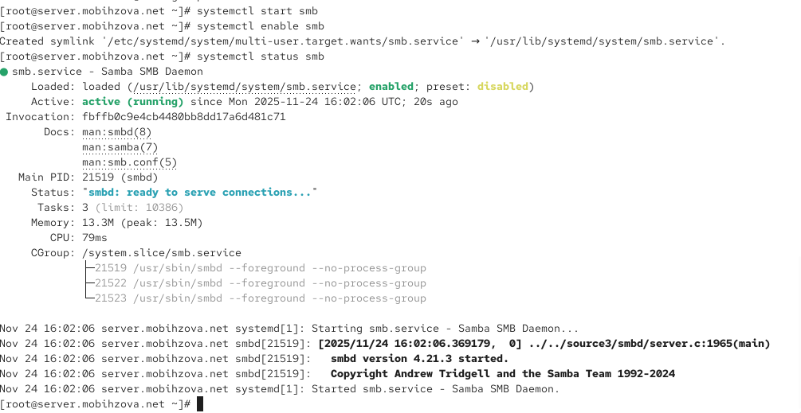

Рисунок 7: Запуск, включение и проверка статуса службы Samba

## Настройка сервера Samba

Проверена доступность общих ресурсов с помощью команды `smbclient` (рис. 8).

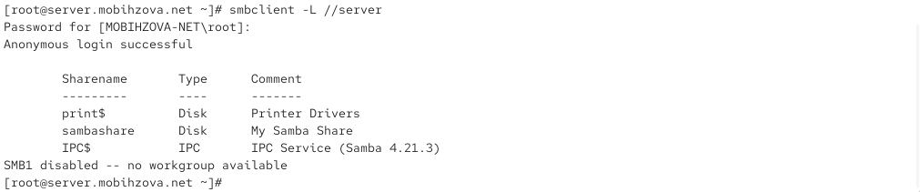

Рисунок 8: Просмотр доступных общих ресурсов через smbclient

## Настройка сервера Samba

Добавлен сервис Samba в исключения файрвола (рис. 9).

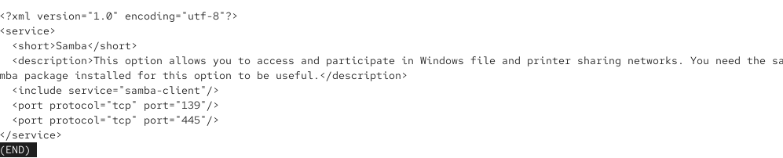

Рисунок 9: Конфигурация сервиса Samba для файрвола

## Настройка сервера Samba

Применены изменения конфигурации файрвола (рис. 10).

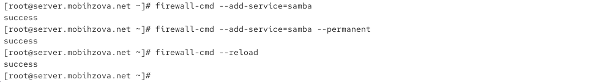

Рисунок 10: Добавление сервиса Samba в файрвол и перезагрузка правил

## Настройка сервера Samba

Настроены права доступа для группы `sambagroup` на каталог общего ресурса (рис. 11).

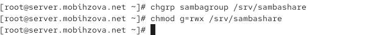

Рисунок 11: Изменение группы владельца и прав доступа для каталога sambashare

## Настройка сервера Samba

Проверен текущий контекст безопасности каталога общего ресурса (рис. 12).

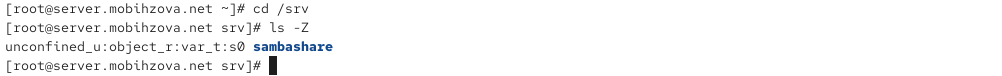

Рисунок 12: Проверка контекста безопасности SELinux для каталога sambashare

## Настройка сервера Samba

Настроен контекст безопасности SELinux для каталога общего ресурса (рис. 13).

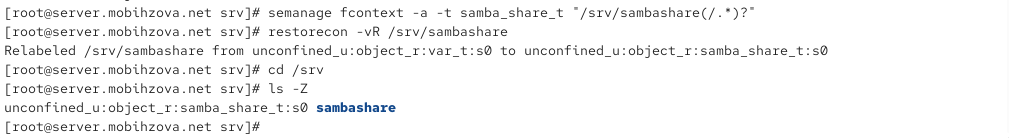

Рисунок 13: Изменение и восстановление контекста безопасности SELinux

## Настройка сервера Samba

Разрешён экспорт ресурсов на запись через SELinux (рис. 14).

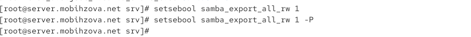

Рисунок 14: Настройка политик SELinux для экспорта ресурсов на запись

## Настройка сервера Samba

Проверены идентификаторы пользователя `mobihzova` (рис. 15).

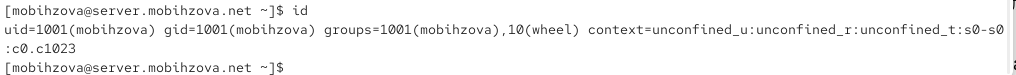

Рисунок 15: Проверка UID и групп пользователя mobihzova

## Настройка сервера Samba

Попытка создания файла пользователем `mobihzova` не удалась из-за недостаточных прав (рис. 16).

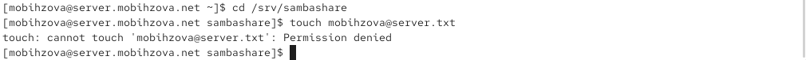

Рисунок 16: Неудачная попытка создания файла пользователем mobihzova

## Настройка сервера Samba

Добавлен пользователь `mobihzova` в базу пользователей Samba (рис. 17).

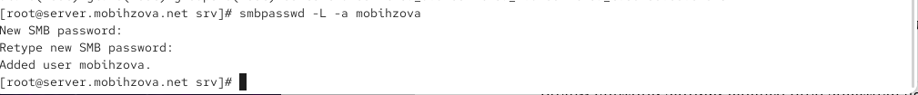

Рисунок 17: Добавление пользователя mobihzova в базу Samba с помощью smbpasswd

## Настройка клиента для доступа к ресурсам Samba

Установлены необходимые пакеты на клиенте для работы с Samba (рис. 18).

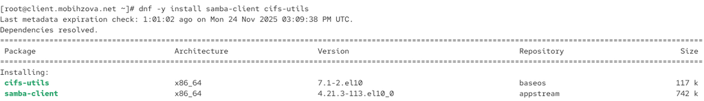

Рисунок 18: Установка пакетов samba-client и cifs-utils на клиенте

## Настройка клиента для доступа к ресурсам Samba

Настроен файрвол на клиенте для работы с Samba (рис. 19).

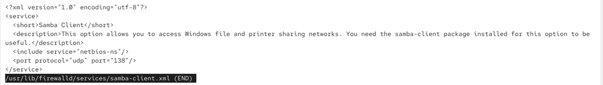

Рисунок 19: Конфигурация сервиса Samba Client для файрвола

## Настройка клиента для доступа к ресурсам Samba

Применены изменения конфигурации файрвола на клиенте (рис. 20).

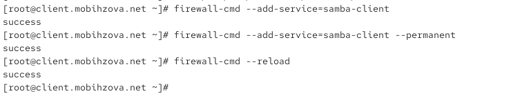

Рисунок 20: Добавление сервиса Samba Client в файрвол и перезагрузка правил

## Настройка клиента для доступа к ресурсам Samba

Создана группа `sambagroup` и добавлен пользователь `mobihzova` на клиенте (рис. 21).

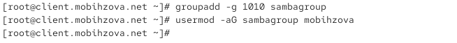

Рисунок 21: Создание группы sambagroup и добавление пользователя mobihzova на клиенте

## Настройка клиента для доступа к ресурсам Samba

Настроен файл конфигурации Samba на клиенте (рис. 22).

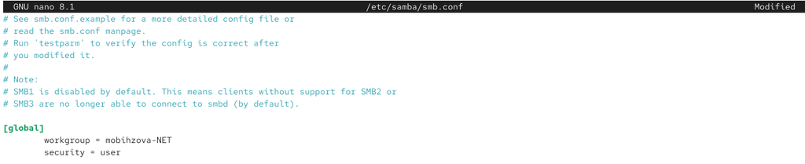

Рисунок 22: Настройка рабочей группы в smb.conf на клиенте

## Настройка клиента для доступа к ресурсам Samba

Проверена доступность общих ресурсов сервера с клиента (рис. 23).

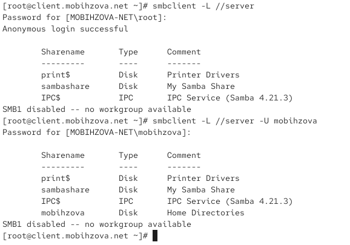

Рисунок 23: Проверка доступности ресурсов сервера с клиента через smbclient

## Настройка клиента для доступа к ресурсам Samba

Смонтирован общий ресурс сервера на клиенте (рис. 25).

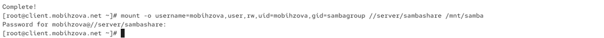

Рисунок 25: Монтирование общего ресурса //server/sambashare на клиенте

## Настройка клиента для доступа к ресурсам Samba

Успешно создан файл на общем ресурсе с клиента (рис. 26).

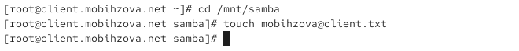

Рисунок 26: Создание файла mobihzova@client.txt на общем ресурсе

## Настройка клиента для доступа к ресурсам Samba

Размонтирован общий ресурс (рис. 27).

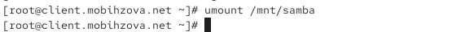

Рисунок 27: Размонтирование общего ресурса

## Настройка клиента для доступа к ресурсам Samba

Создан файл учётных данных для автоматического монтирования (рис. 28).

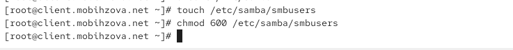

Рисунок 28: Создание файла smbusers для хранения учётных данных

## Настройка клиента для доступа к ресурсам Samba

Настроено содержимое файла учётных данных (рис. 29).

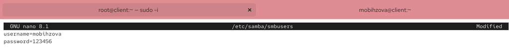

Рисунок 29: Содержимое файла smbusers с учётными данными пользователя

## Создание скриптов для автоматической настройки через Vagrant

Создана структура каталогов для хранения конфигурации Samba на сервере (рис. 32).

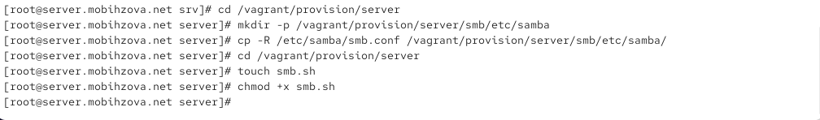

Рисунок 32: Создание каталогов и копирование конфигурационных файлов Samba на сервере